# Simulation R lab - live coding

```r
#Libraries
library(tidyverse)
#Parameters
set.seed(12345)
```

## 1. Generating random numbers

1. Generate 1000 random samples from a normal distribution with a mean of 100 and a standard deviation of 10

```r
mySamples <- rnorm(1000,mean = 100, sd = 10)
mySampleDf <- tibble(samples = mySamples) #convert from a vector of values to a data frame
```

Show the histogram of the data.

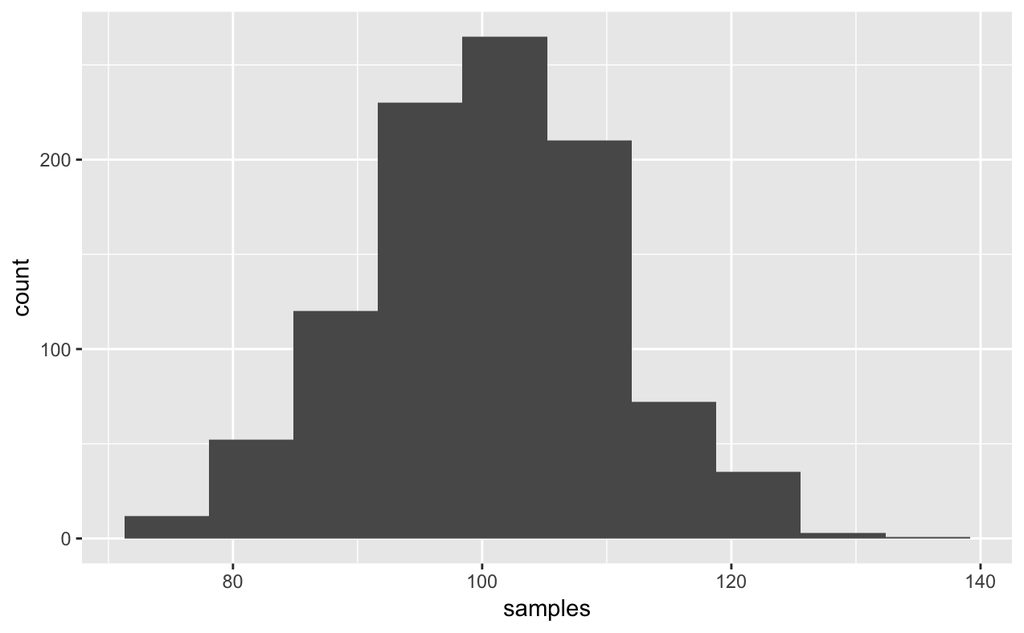

```r
mySampleDf %>%
  ggplot(aes(samples)) +
  geom_histogram(bins = 10)
```

Compute the mean and standard deviation of those data

```r
mySampleDf %>%
  summarise(
    myMean = mean(samples),
    mySd = sd(samples)
  )
```

| myMean | mySd |
| --- | --- |
| 100.462 | 9.987476 |

Add 10 to the data and see how it affects the mean and standard deviation.

```r
mySampleDf %>%
  mutate(samples = samples + 10) %>%
  summarise(
    myMean = mean(samples),
    mySd = sd(samples)
  )
```

| myMean | mySd |
| --- | --- |
| 110.462 | 9.987476 |

Multiply the data by 2 and see how it affects the mean and standard deviation

```r
mySampleDf %>%
  mutate(samples = samples*2) %>%
  summarise(
    myMean = mean(samples),
    mySd = sd(samples)
  )
```

| myMean | mySd |
| --- | --- |
| 200.924 | 19.97495 |

## 2. Sampling with and without replacement

Generate a set of 10 unique random integers from 1 to 20, using a uniform distribution.

```r
myIntegers <- sample.int(20, size = 10, replace = FALSE)
myIntegerDf <- tibble(samples = myIntegers)
```

Take a sample of size 8 from the dataset, without replacement.

```r
myIntegerSampleNoReplace <-
  myIntegerDf %>%
  sample_n(size = 8,replace = FALSE)
unique(myIntegerSampleNoReplace) #return only unique numbers (don't print duplicates)
```

| samples |
| --- |
| 20 |
| 4 |
| 16 |
| 12 |
| 11 |
| 17 |
| 10 |
| 13 |

Take a sample of size 30 from the dataset, without replacement. Why doesn’t this work?

```r
myIntegerSampleNoReplace <-
  myIntegerDf %>%
  sample_n(size = 30, replace = FALSE)
```

```
Error: `size` must be less or equal than 10 (size of data), set `replace` = TRUE to use sampling with replacement
Call `rlang::last_error()` to see a backtrace
```

Take a sample of 30 from the dataset, with replacement. Why does this work?

```r
myIntegerSampleWithReplace <-
  myIntegerDf %>%
  sample_n(30, replace = TRUE)
```

## 3. Sum of squared errors

```r
testData
```

```
[1] 1 2 3 4
```

Compute the sum of squared errors from each of the data points.

```r
print(ssevals)
```

```
[1] 14  6  6 14
```

Compute the sum of squared errors from the mean

```r
sseMean <- sum((testDataMean - testData)^2)
print(sseMean)
```

```
[1] 5
```

## 4. Standard deviation and cumulative distributions

Generate a random sample of size 10,000 with a mean of zero and a standard deviation of 1.

```r
myNormalSamples <- rnorm(10000)
myNormalSamplesDf <-
  tibble(
    samples = myNormalSamples
  )
```

Plot a histogram for these data.

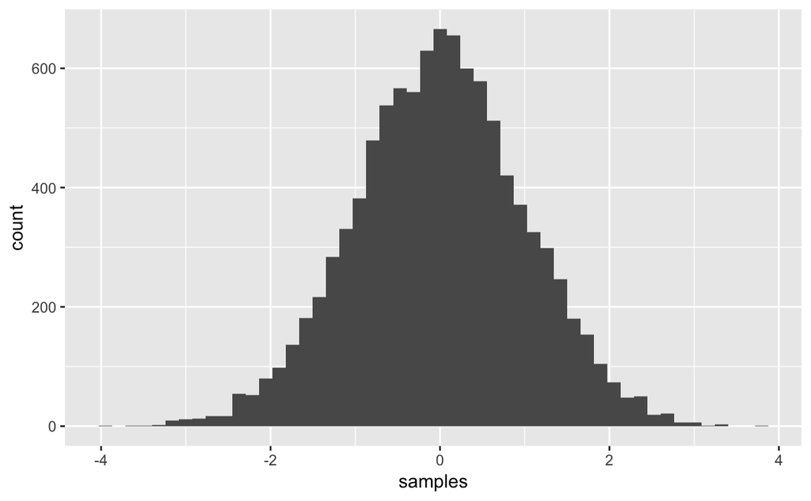

```r
myNormalSamplesDf %>%
  ggplot(aes(samples)) +
  geom_histogram(bins=50)
```

Plot a cumulative distribution for these data.

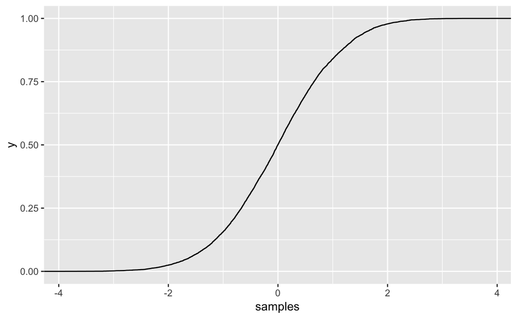

```r
myNormalSamplesDf %>%
  ggplot(aes(samples)) +
  stat_ecdf()
```

```r
NA
```

What proportion of data points fall within the mean +/- 1 standard deviation?

```r
myMean <- mean(myNormalSamplesDf$samples)
mySd <- sd(myNormalSamplesDf$samples)
myNormalSamplesDf <-
  myNormalSamplesDf %>%
  mutate(
    lessthan1sd = samples < (myMean - mySd),
    greaterthan1sd = samples > (myMean + mySd),
    inside1sd = !lessthan1sd & !greaterthan1sd
  )
mean(myNormalSamplesDf$inside1sd)
```

```
[1] 0.6831
```

What about 2 standard deviations?

```r
myNormalSamplesDf <- myNormalSamplesDf %>%
  mutate(
    lessthan2sd = samples < (myMean - 2 * mySd),
    greaterthan2sd = samples > (myMean + 2 * mySd),
    inside2sd = !lessthan2sd & !greaterthan2sd
  )
mean(myNormalSamplesDf$inside2sd)
```

```
[1] 0.9533
```